# Tugas-Pertemuan-2

# Double Moving Average

## Pemulusan dan Peramalan dengan DMA n=5

```r
dma <- SMA(data.sma, n = 5)

At <- 2 * data.sma - dma
Bt <- (2 / (5 - 1)) * (data.sma - dma)

data.dma <- At + Bt # Ini cuma cover sebanyak 100 periode (data train)

data.ramal2 <- c(NA, data.dma)

f = c()

# Untuk nilai peramalan 25 periode ke depan (data test)
for (i in 1:25) {
  f[i] = At[length(At)] + i * Bt[length(Bt)]
}

data.gab2 <- cbind(
  aktual =  c(dataaqi.ts),
  pemulusan1 = c(data.sma,rep(NA,25)),
  pemulusan2 = c(dma,rep(NA,25)),
  At = c(At,rep(NA,25)),
  Bt = c(Bt,rep(NA,25)),
  peramalan = c(data.ramal2, f[-1]))
data.gab2
```

```
##        aktual pemulusan1 pemulusan2    At    Bt peramalan
##   [1,]     64         NA         NA    NA    NA        NA
##   [2,]     65         NA         NA    NA    NA        NA
##   [3,]     62         NA         NA    NA    NA        NA
##   [4,]     63         NA         NA    NA    NA        NA
##   [5,]     60       62.8         NA    NA    NA        NA
##   [6,]     62       62.4         NA    NA    NA        NA
##   [7,]     63       62.0         NA    NA    NA        NA
##   [8,]     58       61.2         NA    NA    NA        NA
##   [9,]     65       61.6      62.00 61.20 -0.20        NA
##  [10,]     67       63.0      62.04 63.96  0.48     61.00
##  [11,]     66       63.8      62.32 65.28  0.74     64.44
##  [12,]     65       64.2      62.76 65.64  0.72     66.02
##  [13,]     59       64.4      63.40 65.40  0.50     66.36
##  [14,]     67       64.8      64.04 65.56  0.38     65.90
```

[output cut: 111 more lines]

## Visualisasi Data Aktual, Pemulusan, dan Peramalan

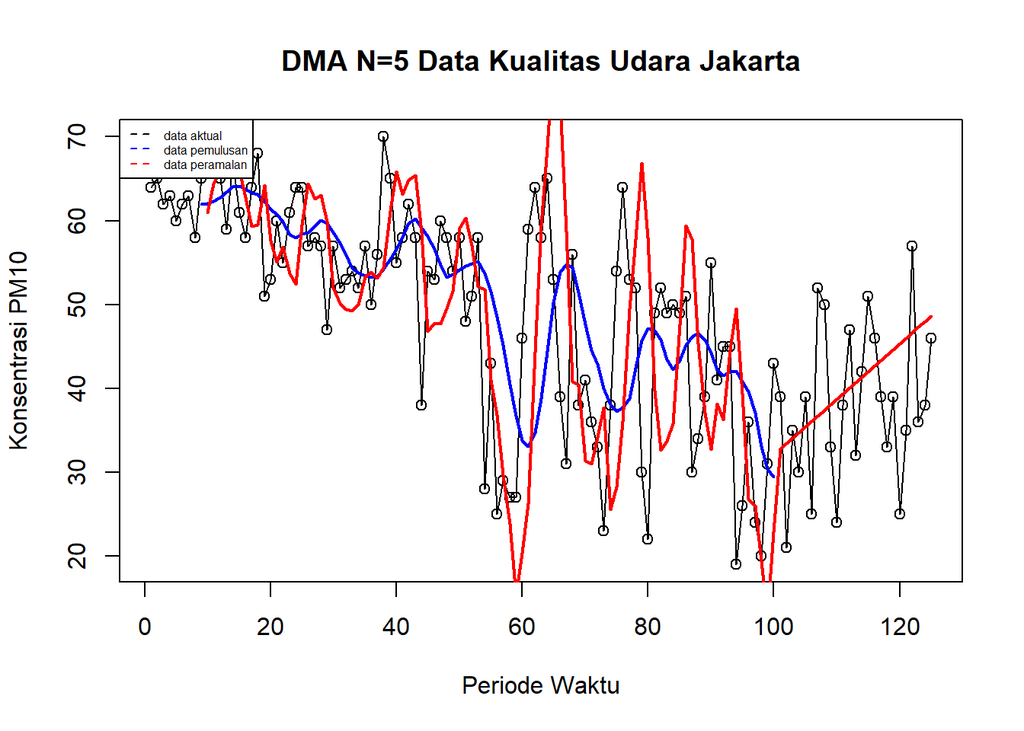

```r
ts.plot(dataaqi.ts, xlab="Periode Waktu", ylab="Konsentrasi PM10", main= "DMA N=5 Data Kualitas Udara Jakarta")
points(dataaqi.ts)
lines(data.gab2[,3],col="blue",lwd=2)
lines(data.gab2[,6],col="red",lwd=2)
legend("topleft",c("data aktual","data pemulusan","data peramalan"), lty=8, col=c("black","blue","red"), cex=0.5)
```

## Akurasi Data Train

```r
errortraindma <- train.ts - data.gab2[1:n_train,6]
SSEtraindma <- sum(errortraindma[10:length(errortraindma)]^2)
MSEtraindma <- mean(errortraindma[10:length(errortraindma)]^2)
MAPEtraindma <- mean(abs(errortraindma[10:length(errortraindma)]/train.ts[10:length(errortraindma)])*100)

akurasitraindma <- matrix(c(SSEtraindma, MSEtraindma, MAPEtraindma))
rownames(akurasitraindma) <- c("SSE", "MSE", "MAPE")
colnames(akurasitraindma) <- c("Akurasi Data Train n=5")
akurasitraindma
```

```
##      Akurasi Data Train n=5
## SSE             17401.74640
## MSE               191.22798
## MAPE               25.54281
```

Akurasi data train dihitung mulai dari periode ke-10 karena pada periode 1 sampai 9, nilai pemulusan ganda (DMA) adalah NA (Not Available). Hasilnya menunjukkan bahwa model DMA dengan n=5 menghasilkan kualitas yang masih belum lebih baik dibanding SMA, bisa dilihat dari MAPE nya yang lebih tinggi yaitu sekitar 25%.

## Akurasi Data Test

```r
errortestdma <- test.ts - data.gab2[101:125,6]
SSEtestdma <- sum(errortestdma^2)
MSEtestdma <- mean(errortestdma^2)
MAPEtestdma <- mean(abs(errortestdma/test.ts)*100)

akurasitestdma <- matrix(c(SSEtestdma, MSEtestdma, MAPEtestdma))
rownames(akurasitestdma) <- c("SSE", "MSE", "MAPE")
colnames(akurasitestdma) <- c("Akurasi Data Test n=5")
akurasitestdma
```

```
##      Akurasi Data Test n=5
## SSE             2250.93000
## MSE               90.03720
## MAPE              24.13641
```

# Single Exponential Smoothing

## Pemulusan dan Peramalan dengan SES alpha optimum

### Fungsi SES

```r
data.ses <- ses(train.ts, alpha = NULL, h = 25)
data.ses
```

```
##     Point Forecast      Lo 80    Hi 80       Lo 95    Hi 95
## 101       37.22026 24.6747377 49.76577  18.0335417 56.40697
## 102       37.22026 22.4710219 51.96949  14.6632493 59.77726
## 103       37.22026 20.5562295 53.88428  11.7348270 62.70568
## 104       37.22026 18.8398410 55.60067   9.1098373 65.33067
## 105       37.22026 17.2705811 57.16993   6.7098614 67.73065
## 106       37.22026 15.8160647 58.62445   4.4853706 69.95514
## 107       37.22026 14.4542884 59.98622   2.4027135 72.03780
## 108       37.22026 13.1694940 61.27102   0.4377899 74.00272
## 109       37.22026 11.9499369 62.49057  -1.4273617 75.86787
## 110       37.22026 10.7865861 63.65392  -3.2065531 77.64706
## 111       37.22026  9.6723200 64.76819  -4.9106761 79.35119
## 112       37.22026  8.6014047 65.83911  -6.5484998 80.98901
## 113       37.22026  7.5691426 66.87137  -8.1272084 82.56772
## 114       37.22026  6.5716280 67.86888  -9.6527754 84.09329
## 115       37.22026  5.6055715 68.83494 -11.1302312 85.57074
## 116       37.22026  4.6681724 69.77234 -12.5638595 87.00437
## 117       37.22026  3.7570221 70.68349 -13.9573436 88.39785
## 118       37.22026  2.8700319 71.57048 -15.3138780 89.75439
## 119       37.22026  2.0053761 72.43513 -16.6362550 91.07677
## 120       37.22026  1.1614479 73.27906 -17.9269318 92.36744
## 121       37.22026  0.3368245 74.10369 -19.1880844 93.62860
## 122       37.22026 -0.4697611 74.91027 -20.4216507 94.86216
## 123       37.22026 -1.2594434 75.69995 -21.6293655 96.06988
## 124       37.22026 -2.0332424 76.47375 -22.8127890 97.25330
## 125       37.22026 -2.7920798 77.23259 -23.9733306 98.41384
```

Berikut adalah hasil pemulusan dan peramalan dengan single exponential smoothing (SES) menggunakan alpha optimum yang diperoleh dari fungsi ses(). Diperoleh nilai tengah peramalan berada di angka 37.22.

### Fungsi HoltWinters

```r
data.sesh <- HoltWinters(train.ts, alpha = NULL, beta = FALSE, gamma = FALSE)
data.sesh
```

```
## Holt-Winters exponential smoothing without trend and without seasonal component.
##
## Call:
## HoltWinters(x = train.ts, alpha = NULL, beta = FALSE, gamma = FALSE)
##
## Smoothing parameters:
##  alpha: 0.6181637
##  beta : FALSE
##  gamma: FALSE
##
## Coefficients:
##       [,1]
## a 37.21965
```

```r
data.ramalsesh <- forecast(data.sesh, h = 25)
data.ramalsesh
```

```
##     Point Forecast      Lo 80    Hi 80       Lo 95    Hi 95
## 101       37.21965 24.6867996 49.75250  18.0523092 56.38699
## 102       37.21965 22.4855460 51.95375  14.6857824 59.75352
## 103       37.21965 20.5728695 53.86643  11.7605961 62.67870
## 104       37.21965 18.8583651 55.58094   9.1384880 65.30081
## 105       37.21965 17.2908201 57.14848   6.7411347 67.69817
## 106       37.21965 15.8378881 58.60141   4.5190669 69.92023
## 107       37.21965 14.4775915 59.96171   2.4386729 72.00063
## 108       37.21965 13.1941905 61.24511   0.4758804 73.96342
## 109       37.21965 11.9759541 62.46335  -1.3872515 75.82655
## 110       37.21965 10.8138615 63.62544  -3.1645186 77.60382
## 111       37.21965  9.7007992 64.73850  -4.8668005 79.30610
## 112       37.21965  8.6310399 65.80826  -6.5028562 80.94216
## 113       37.21965  7.5998913 66.83941  -8.0798620 82.51916
## 114       37.21965  6.6034519 67.83585  -9.6037845 84.04308
## 115       37.21965  5.6384361 68.80086 -11.0796487 85.51895
## 116       37.21965  4.7020463 69.73725 -12.5117334 86.95103
## 117       37.21965  3.7918766 70.64742 -13.9037178 88.34302
## 118       37.21965  2.9058406 71.53346 -15.2587929 89.69809
## 119       37.21965  2.0421147 72.39719 -16.5797478 91.01905
## 120       37.21965  1.1990937 73.24021 -17.8690370 92.30834
## 121       37.21965  0.3753566 74.06394 -19.1288342 93.56813
## 122       37.21965 -0.4303624 74.86966 -20.3610752 94.80038
## 123       37.21965 -1.2191965 75.65850 -21.5674927 96.00679
## 124       37.21965 -1.9921645 76.43146 -22.7496453 97.18895
## 125       37.21965 -2.7501871 77.18949 -23.9089409 98.34824
```

Sementara pada fungsi HoltWinters, diperoleh nilai tengah peramalan JUGA berada di angka 37.22. Nilai alpha optimum yang diperoleh dari fungsi HoltWinters adalah 0.62.